# Report: Wash data checks

Steve and Jonathan

2020-01-12

## Variables

Distribution of missing cases for each of the variables. - Although `hungerscale` and `belowpovertyline` have more proportion of missing cases, `wealthindex` is used as a proxy for the two.

| variable | miss_count | miss_prop |
| --- | --- | --- |
| hungerscale | 55436 | 21.6 |
| belowpovertyline | 55256 | 21.6 |
| hhsize | 929 | 0.4 |
| ethnicity | 673 | 0.3 |
| watersource | 0 | 0 |
| toilettype | 0 | 0 |
| garbagedposal | 0 | 0 |
| age | 0 | 0 |
| gender | 0 | 0 |
| slumarea | 0 | 0 |

[output cut: 4 more lines]

- **Fixed effect variables**
  - `age`
  - `gender`
  - `slumarea` - Slum area (Korogocho or Viwandani)
  - `hhsize` - number of people living in the household as at survey
  - `wealthindex` - The wealth index was constructed using principle component analysis (PCA) with input as indicator variables on ownership of household and individual assets/items (such as TV, electricity, fridge, radio, bicycle, motorcycle, shoes, blanket, clothes, etc.), and nature of their housing
  - `StatusP` - Aavailability of service in the previous year (0/1)
- **Random effect variables**
  - `(services|hhid)` - correlated, time-independent variation among households
  - `(services|years)` - correlated, household-independent variation across years
- **Response variables**

**Improved**

**Unimproved**

- **Drinking water source**
- Piped water into dwelling, plot or yard
- Public tap/standpipe
- Tube well / borehole
- Protected dug well with hand pump
- Protected spring
- Rainwater collection from the roof
- Unprotected dug well
- Unprotected spring
- Small water vendor (cart with small tank or drum)
- Bottled water
- Tanker truck
- Rainwater collection from surface run off. Surface water (river, dam, lake, pond, stream, canal, irrigation channels)
- Protected dug well with bucket
- **Toilet facility type**
- Flush / pour flush to piped sewer system or septic tank or pit latrine
- VIP latrine
- Pit latrine with slab
- Composting toilet
- Flush / pour flush to elsewhere e.g. to open drain
- Pit latrine without slab (slab with holes) /open pit
- Bucket
- Hanging toilet / hanging latrine
- No facilities or bush or field
- **Garbage disposal method**
- Garbage dump
- Private pits
- Public pits
- Proper garbage disposal services
- Other organized groups such as the national youth service
- In the river
- On the road, railway line/station
- In drainage/sewage/t rench
- Vacant/abandoned house/plot/field
- No designated place/all over
- Street boys/urchins
- Burning
- Other

## Data format choices

There two choices to be made:

- **Consecutive year interviews per household**: We assume that households conducted interviews every year. Consequently, a case missing an interview in the previous (immediate) year is droped (43.2%). See the Figure below. Model fitted based on this has a `_consec` tag.

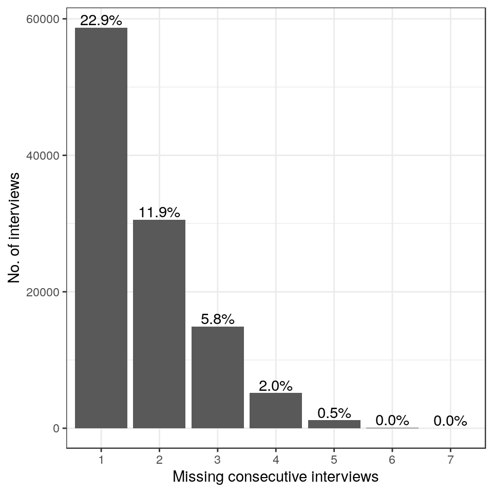

- The 43.2% includes first year (specific to household) cases which do not have the previous years. These are dropped by model matrix. Thus the proportion of interviews we are actually dropping due to missing previous (immediate) interviews is 11.8%.

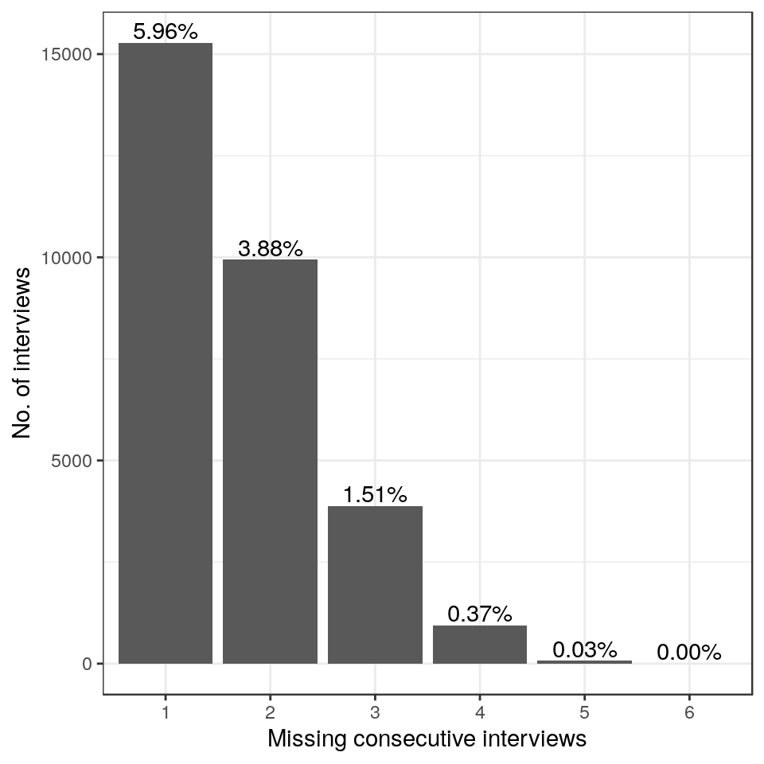

- **Lagged interviews**: Any household interview (most recent) preceding the current household interview is considered consecutive interview. In this case, only interviews in the first year (household specific) will have missing previous year. Consequently, only first year interviews will be dropped (31.4%). Model fitted based on this has `_lagged` tag.
- **Thoughts**
  - Should we impute services for the previous year in the first year (household specific)?

## Estimates

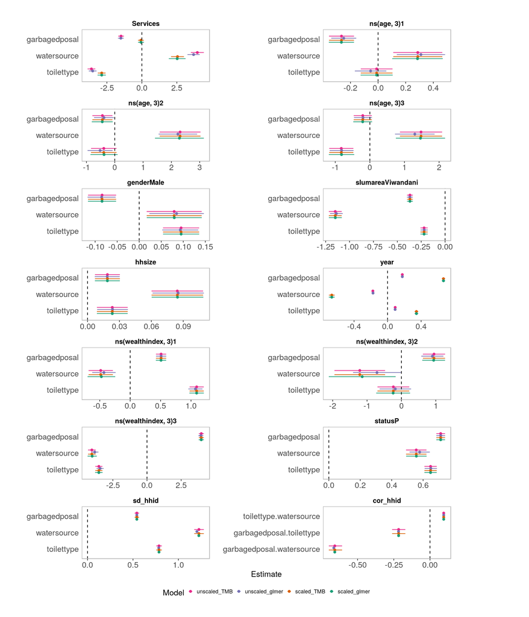

## Predictor effect plots

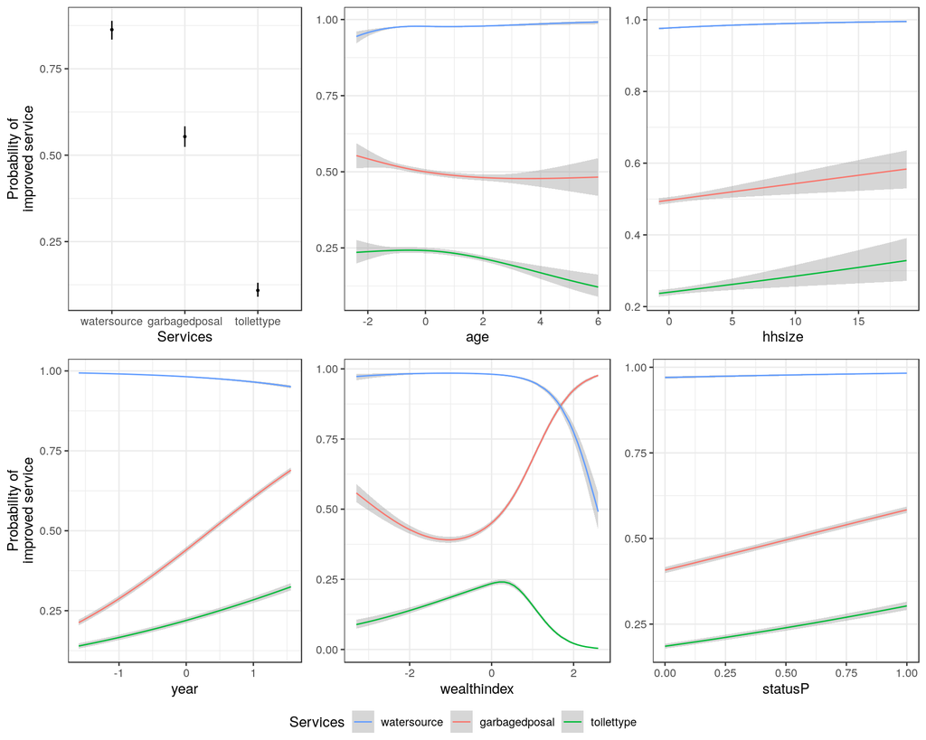

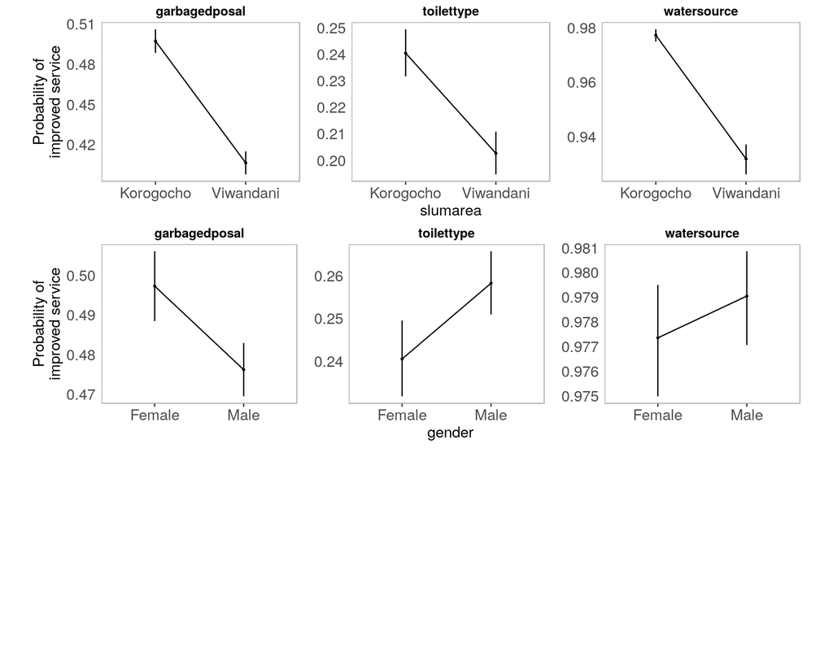